# HNC Tumour Marker Identification — Analysis Report

TCGA-HNSC & GSE65858 | HPV-Negative | All HNC Sites | Combined Score Ranking

Khushi Bhardwaj

2026-04-15

# 1. Overview

This report summarises the bioinformatic identification of candidate tumour markers for head and neck cancer (HNC), intended to guide wet-lab validation via immunofluorescence (IF) and H&E staining on patient-derived tumouroids.

**Analysis parameters:**

- **Datasets:** TCGA-HNSC (Pan-Can Atlas 2018) and GSE65858
- **HPV status:** HPV-negative only
- **Anatomical sites:** All HNC sites pooled; lip and nasopharynx excluded from GSE65858
- **Ranking method:** Combined score (scaled log2 fold change + scaled log10 base mean) — prioritises genes that are both strongly upregulated AND highly expressed
- **Approach:** Independent analysis per dataset, followed by cross-dataset consensus ranking

**Sample sizes:**

| Dataset | Tumour | Normal | Notes |
| --- | --- | --- | --- |
| TCGA-HNSC | 520 | 44 | Matched adjacent normal tissue; RNA-seq counts |
| GSE65858 | 196 | 0 | HPV-negative primary/relapse/secondary tumours; microarray |

**Note on site annotation:** GSE65858 site metadata was insufficient for fine-grained site filtering without prohibitively reducing sample sizes, so all HNC sites were included in both datasets.

# 2. Analytical Approach

## 2.1 Why Combined Score Ranking?

Initial analysis ranked genes by log2 fold change alone. While this identifies genes most *switched on* in tumour vs. normal, it disproportionately favours cancer-testis antigens (e.g. MAGE family) which have near-zero normal tissue expression, inflating their fold change.

A combined score was introduced to balance two complementary metrics:

- **log2 Fold Change** — how specifically upregulated is the gene in tumour vs. normal?
- **baseMean (log10-scaled)** — how abundantly and consistently is the gene expressed across all samples?

```
Combined Score = scale(log2FC) + scale(log10(baseMean))
```

This ensures that clinically and biologically relevant markers with high absolute expression (e.g. MMP1, MMP13, CA9) score alongside highly specific but lower-expressed genes.

# 3. Dataset 1: TCGA-HNSC

## 3.1 Differential Expression (DESeq2)

TCGA-HNSC RNA-seq count data was downloaded via TCGAbiolinks and processed using DESeq2. Low-expression genes were removed (< 10 counts in < 10 samples), leaving **29,771 genes** for testing.

**Result:** 5,556 genes were significantly upregulated in tumour vs. normal (padj < 0.05, log2FC > 1).

## 3.2 Volcano Plot — Combined Score Top 30

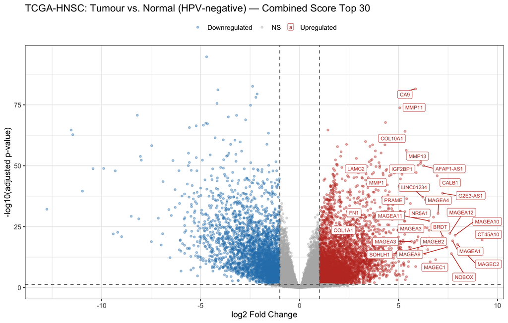

```r
library(tidyverse)
library(ggrepel)

ggplot(tcga_res_df, aes(x = log2FoldChange, y = neg_log10_p, colour = sig)) +
  geom_point(alpha = 0.4, size = 1.2) +
  geom_label_repel(
    data         = top30_tcga_combined,
    aes(label    = gene_symbol),
    size         = 2.8,
    max.overlaps = 25
  ) +
  scale_colour_manual(values = c(
    "Upregulated"   = "#C0392B",
    "Downregulated" = "#2980B9",
    "NS"            = "grey70"
  )) +
  geom_vline(xintercept = c(-1, 1), linetype = "dashed", colour = "grey40") +
  geom_hline(yintercept = -log10(0.05), linetype = "dashed", colour = "grey40") +
  labs(
    title  = "TCGA-HNSC: Tumour vs. Normal (HPV-negative) — Combined Score Top 30",
    x      = "log2 Fold Change",
    y      = "-log10(adjusted p-value)",
    colour = NULL
  ) +
  theme_bw(base_size = 13) +
  theme(legend.position = "top")
```

## 3.3 Top 30 Combined Score Genes

```r
library(knitr)

tcga_combined %>%
  dplyr::rename(
    Gene              = gene_symbol,
    `log2FC`          = log2FoldChange,
    `Base Mean`       = baseMean,
    `Combined Score`  = combined_score,
    `Adj. p-value`    = padj
  ) %>%
  mutate(
    `log2FC`         = round(`log2FC`, 3),
    `Base Mean`      = round(`Base Mean`, 1),
    `Combined Score` = round(`Combined Score`, 3),
    `Adj. p-value`   = formatC(`Adj. p-value`, format = "e", digits = 2)
  ) %>%
  kable(caption = "Top 30 upregulated genes in TCGA-HNSC tumour vs. normal (HPV-negative), ranked by combined score")
```

Top 30 upregulated genes in TCGA-HNSC tumour vs. normal (HPV-negative), ranked by combined score

[output not shown]

## 3.4 TCGA Heatmap — Top 30 Combined Score Genes

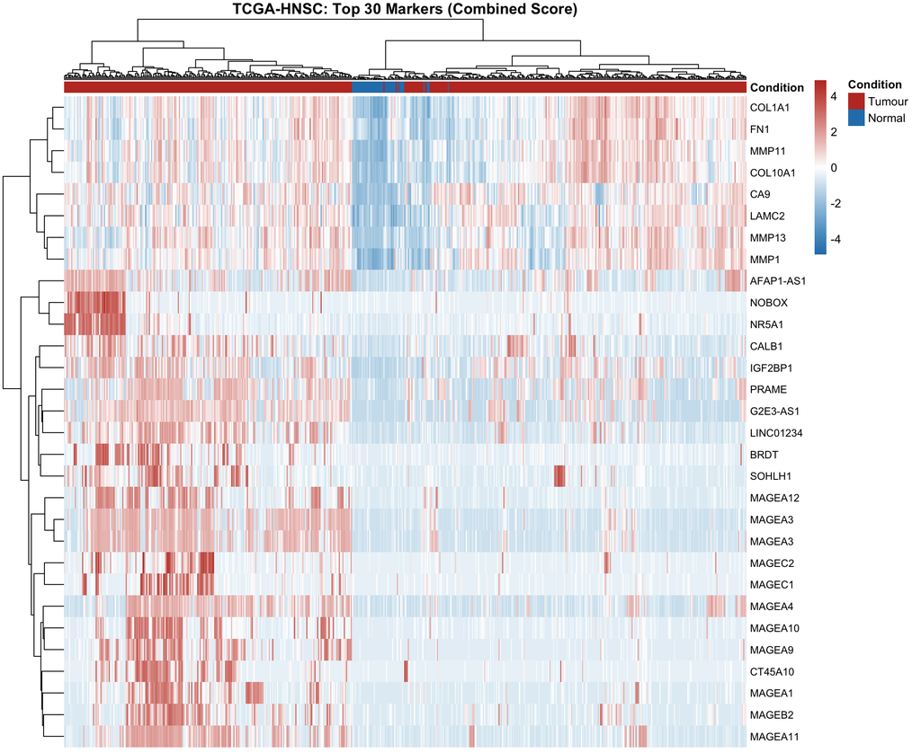

Heatmap of top 30 combined-score genes across TCGA-HNSC tumour and normal samples. Rows z-score scaled. Clear separation between tumour (red) and normal (blue) conditions. MMP/structural genes cluster separately from MAGE cancer-testis antigens.

```r
library(pheatmap)
library(DESeq2)

tcga_vst          <- vst(dds, blind = FALSE)
top30_genes_combined <- top30_tcga_combined$gene[!is.na(top30_tcga_combined$gene)]
heatmap_mat_tcga  <- assay(tcga_vst)[top30_genes_combined, ]
rownames(heatmap_mat_tcga) <- top30_tcga_combined$gene_symbol[
  match(rownames(heatmap_mat_tcga), top30_tcga_combined$gene)
]

anno_col_tcga <- data.frame(
  Condition = tcga_meta$condition,
  row.names = colnames(heatmap_mat_tcga)
)

pheatmap(
  heatmap_mat_tcga,
  annotation_col    = anno_col_tcga,
  annotation_colors = list(Condition = c(Tumour = "#C0392B", Normal = "#2980B9")),
  show_colnames     = FALSE,
  scale             = "row",
  color             = colorRampPalette(c("#2980B9", "white", "#C0392B"))(100),
  main              = "TCGA-HNSC: Top 30 Markers (Combined Score)",
  fontsize_row      = 9,
  clustering_method = "ward.D2"
)
```

# 4. Dataset 2: GSE65858 — Cross-Validation

## 4.1 Dataset Description

GSE65858 is a microarray dataset (Illumina HumanHT-12 V4.0) comprising 270 HNSCC tumour samples with rich clinical annotation. As this dataset contains **tumour samples only**, it was used for cross-validation of TCGA-derived markers — confirming which markers are also consistently and highly expressed in an independent HPV-negative cohort.

**Cohort composition after filtering:**

| Tumour Type | n |
| --- | --- |
| Primary | 179 |
| Secondary | 14 |
| Relapse | 3 |
| **Total** | **196** |

| Anatomical Site | n |
| --- | --- |
| Cavum Oris | 70 |
| Oropharynx | 47 |
| Larynx | 45 |
| Hypopharynx | 30 |
| NA | 4 |

## 4.2 Cross-Validation Results

The global expression median across GSE65858 was **6.76**. Genes with mean expression above this threshold were considered consistently expressed across the independent cohort.

**Genes above GSE65858 global median:**

| Gene | GSE65858 Mean | Interpretation |
| --- | --- | --- |
| MMP1 | 9.77 | Far above median — most consistently expressed gene in cohort |
| MMP11 | 8.39 | Well above median |
| MAGEA4 | 7.54 | Above median — best MAGE family candidate |
| CA9 | 7.43 | Above median — broad tumour expression |
| MMP13 | 7.28 | Above median |
| PRAME | 7.22 | Above median |
| MAGEA10 | 6.99 | Marginally above median |
| MAGEA1 | 6.99 | Marginally above median |
| COL10A1 | 6.85 | Marginally above median |

## 4.3 GSE65858 Consensus Heatmap

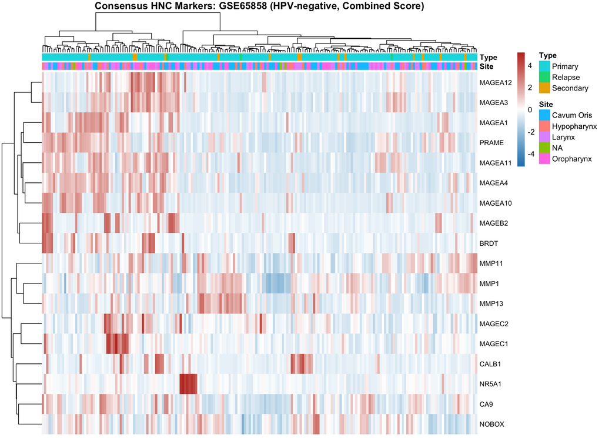

```r
heatmap_genes_v2 <- unique(consensus_table_v2$Gene[1:20])
heatmap_mat_gse  <- as.matrix(gse_expr_final[heatmap_genes_v2, ])

anno_col_gse <- data.frame(
  Site = gse_meta_filt$`tumor_site:ch1`,
  Type = gse_meta_filt$`tumor_type:ch1`,
  row.names = colnames(heatmap_mat_gse)
)

pheatmap(
  heatmap_mat_gse,
  annotation_col           = anno_col_gse,
  show_colnames            = FALSE,
  scale                    = "row",
  color                    = colorRampPalette(c("#2980B9", "white", "#C0392B"))(100),
  main                     = "Consensus HNC Markers: GSE65858 (HPV-negative, Combined Score)",
  fontsize_row             = 9,
  clustering_distance_cols = "euclidean",
  clustering_method        = "ward.D2"
)
```

# 5. Consensus Marker Table

```r
consensus_table_v2 %>%
  dplyr::rename(
    Gene                  = Gene,
    `TCGA log2FC`         = TCGA_log2FC,
    `TCGA baseMean`       = TCGA_baseMean,
    `TCGA Combined Score` = TCGA_CombinedScore,
    `GSE65858 Mean`       = GSE65858_meanExpr,
    `Above GSE Median`    = AboveGSEMedian,
    `Final Score`         = FinalScore
  ) %>%
  mutate(
    `TCGA log2FC`         = round(`TCGA log2FC`, 3),
    `TCGA baseMean`       = round(`TCGA baseMean`, 1),
    `TCGA Combined Score` = round(`TCGA Combined Score`, 3),
    `GSE65858 Mean`       = round(`GSE65858 Mean`, 3),
    `Final Score`         = round(`Final Score`, 3)
  ) %>%
  kable(caption = "Consensus marker table ranked by final score (TCGA combined score + GSE65858 expression). Above GSE Median = TRUE indicates consistent expression across independent HPV-negative cohort.")
```

Consensus marker table ranked by final score (TCGA combined score + GSE65858 expression). Above GSE Median = TRUE indicates consistent expression across independent HPV-negative cohort.

| Gene | TCGA log2FC | TCGA baseMean | TCGA Combined Score | GSE65858 Mean | Above GSE Median | Final Score |
| --- | --- | --- | --- | --- | --- | --- |
| MMP1 | 4.534 | 28786.4 | 4.901 | 9.773 | TRUE | 2.921 |
| MAGEA4 | 6.994 | 2293.5 | 6.371 | 7.540 | TRUE | 2.429 |
| MMP13 | 6.108 | 9496.6 | 6.034 | 7.278 | TRUE | 1.521 |
| MAGEA1 | 7.728 | 234.0 | 6.233 | 6.993 | TRUE | 1.479 |
| MAGEA10 | 7.857 | 150.8 | 6.195 | 6.994 | TRUE | 1.415 |
| MMP11 | 5.061 | 9313.5 | 4.994 | 8.390 | TRUE | 1.251 |
| MAGEA12 | 7.591 | 281.6 | 6.168 | 6.661 | FALSE | 0.931 |
| CALB1 | 6.952 | 1432.7 | 6.152 | 6.495 | FALSE | 0.686 |
| CA9 | 5.856 | 1800.2 | 5.158 | 7.427 | TRUE | 0.255 |
| MAGEC2 | 7.976 | 44.6 | 5.852 | 6.502 | FALSE | 0.194 |
| MAGEB2 | 7.229 | 172.1 | 5.626 | 6.660 | FALSE | 0.024 |
| MAGEA3 | 6.444 | 914.4 | 5.482 | 6.745 | FALSE | -0.104 |
| MAGEA3 | 6.444 | 914.4 | 5.482 | 6.745 | FALSE | -0.104 |
| NOBOX | 7.670 | 58.2 | 5.651 | 6.398 | FALSE | -0.281 |
| MAGEA11 | 6.533 | 384.4 | 5.242 | 6.578 | FALSE | -0.725 |
| NR5A1 | 6.766 | 236.4 | 5.289 | 6.372 | FALSE | -0.919 |
| PRAME | 5.598 | 851.9 | 4.621 | 7.217 | TRUE | -0.919 |
| BRDT | 7.228 | 61.1 | 5.234 | 6.364 | FALSE | -1.021 |
| MAGEC1 | 6.872 | 83.9 | 5.003 | 6.442 | FALSE | -1.304 |
| MAGEA3 | 5.655 | 980.5 | 4.731 | 6.745 | FALSE | -1.358 |
| MAGEA3 | 5.655 | 980.5 | 4.731 | 6.745 | FALSE | -1.358 |
| COL10A1 | 5.327 | 1740.6 | 4.624 | 6.850 | TRUE | -1.398 |
| CTAG2 | 6.598 | 57.0 | 4.586 | 6.655 | FALSE | -1.719 |
| SOHLH1 | 6.417 | 93.8 | 4.596 | 6.508 | FALSE | -1.896 |

# 6. Recommended Marker Panel

Based on cross-dataset performance, statistical robustness, expression breadth, and suitability for immunofluorescence detection, the following 5-marker panel is recommended for wet-lab validation:

## 6.1 Priority Tier 1 — Broad expression, strongest cross-dataset evidence

| Rank | Gene | TCGA baseMean | GSE65858 Mean | Rationale |
| --- | --- | --- | --- | --- |
| 1 | **MMP1** | 28,786 | 9.77 | Highest expressed gene across both datasets. Matrix metalloproteinase, secreted/extracellular — excellent IF candidate. Well-validated antibodies. |
| 2 | **MMP13** | 9,497 | 7.28 | Extremely significant (padj 10⁻⁵¹), very high baseMean, above GSE median. Established role in HNC invasion. |
| 3 | **MMP11** | 9,314 | 8.39 | High expression in both datasets. Stromal MMP with strong tumour association. |
| 4 | **CA9** | 1,800 | 7.43 | Classic HNSCC hypoxia marker. Cell surface localisation — ideal for IF without permeabilisation. Among the most statistically significant results (padj 10⁻⁸²). |

## 6.2 Priority Tier 2 — Subtype-restricted, cancer-testis antigen

[output not shown]

## 6.3 Exclusion Notes

# 7. Next Steps

1. **Human Protein Atlas & UniProt cross-reference** — confirm antibody availability, validation status, and subcellular localisation for MMP1, MMP13, MMP11, CA9, MAGEA4 before ordering
2. **Tumouroid retention check** — validate marker expression in GSE223554 and OrganoidDB once data access is confirmed; check whether tumouroids retain 70–90% of tumour expression levels
3. **scRNA-seq validation** — use GSE164690 and GSE188737 to verify that top markers are expressed in tumour epithelial cell clusters rather than immune or stromal populations

*Analysis performed by Khushi Bhardwaj. Pipeline built in R 4.4.1 using TCGAbiolinks, DESeq2, GEOquery, limma, org.Hs.eg.db, pheatmap, ggplot2, and associated Bioconductor/CRAN packages. All datasets publicly available; TCGA-HNSC accessed via GDC portal, GSE65858 via NCBI GEO.*